# eimpute: Efficiently IMPUTE Large Scale Incomplete Matrix

## Introduction

Matrix completion is a procedure for imputing the missing elements in matrices by using the information of observed elements. This procedure can be visualized as:

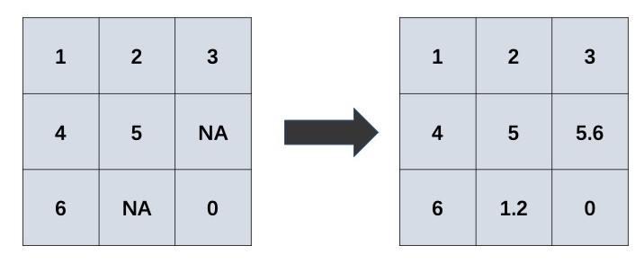

Matrix completion has attracted a lot of attention, it is widely applied in:

- tabular data imputation: recover the missing elements in data table;
- recommend system: estimate users’ potantial preference for items pending purchased;
- image inpainting: inpaint the missing elements in digit images.

A computationally efficient R package, **eimpute** is developed for matrix completion. In **eimpute**, matrix completion problem is solved by iteratively performing low-rank approximation and data calibration, which enjoy two admirable advantages:

- unbiased low-rank approximation for incomplete matrix
- less time consumption via truncated SVD

Compare **eimpute** and **softimpute** in systhesis datasets $X_{m \times m}$ with $p$ proportion missing observations. The square matrix $X_{m \times m}$ is generated by $X = UV + \epsilon$, where $U$ and $V$ are $m \times r$, $r \times n$ matrices whose entries are $i.i.d.$ sampled standard normal distribution, $\epsilon \sim N(0, r/3)$.

- $m$ is chosen as 1000, 2000, 3000, 4000
- $p$ is chosen as 0.1, 0.5, 0.9.

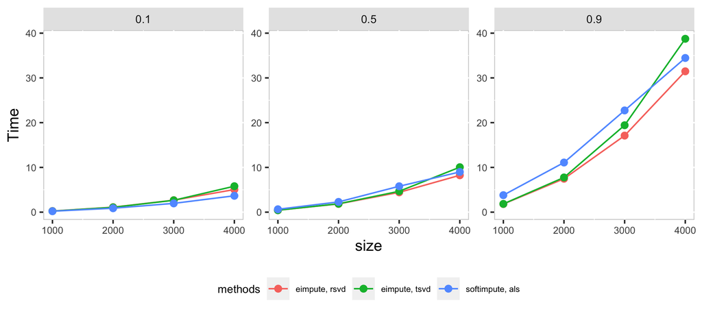

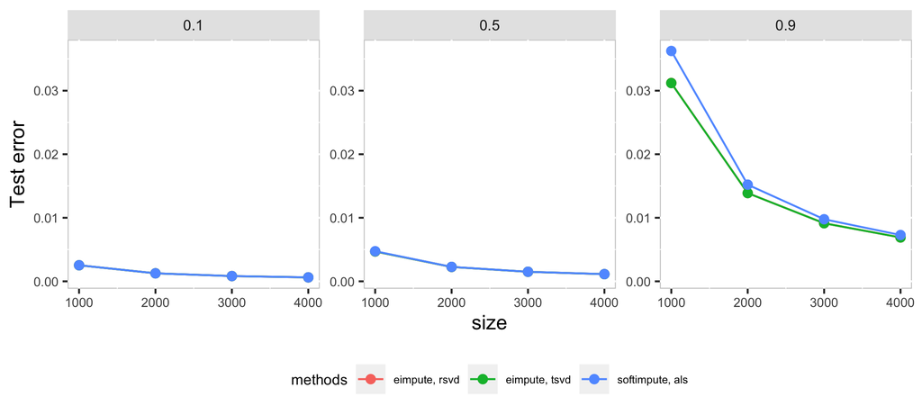

In high dimension case, als method in **softimpute** is a little faster than **eimpute** in low proportion of missing observations, as the proportion of missing observations increase, rsvd method in **eimpute** have a better performance than **softimpute** in time cost and test error. Compare with two method in **eimpute*, rsvd method is better than tsvd in time cost.

## Installation

Install the stable version from CRAN:

```r
install.packages("eimpute")
```

Install the development version from github:

```r
library(devtools)
install_github("Mamba413/eimpute", build_vignettes = TRUE)
```

## Quick Example

We start with a toy example. Let us generate a small matrix with some values missing via **incomplete.generator** function.

```r
m <- 6
n <- 5
r <- 3
x_na <- incomplete.generator(m, n, r)
x_na
```

```
#>            [,1]       [,2]       [,3]      [,4]       [,5]
#> [1,] -0.8269428  1.2228586         NA        NA         NA
#> [2,] -2.2410010  4.5095165         NA        NA         NA
#> [3,]  0.4499102         NA -0.2818085 0.7718102 -0.8364048
#> [4,]         NA  1.7167365  0.9480745        NA  3.5680208
#> [5,]         NA  0.7240437         NA        NA  0.2633712
#> [6,]         NA -2.8879249         NA 1.2027552         NA
```

Use **eimpute** function to impute missing values.

```r
x_impute <- eimpute(x_na, r)
x_impute[["x.imp"]]
```

```
#>            [,1]       [,2]        [,3]      [,4]       [,5]
#> [1,] -0.8269428  1.2228586  0.13491466 1.0447719  0.2282393
#> [2,] -2.2410010  4.5095165  0.39770381 0.6822340  0.5339082
#> [3,]  0.4499102 -1.3677635 -0.28180850 0.7718102 -0.8364048
#> [4,] -0.3943001  1.7167365  0.94807452 0.1739945  3.5680208
#> [5,] -0.3806827  0.7240437  0.10760699 0.3276512  0.2633712
#> [6,]  1.2748929 -2.8879249 -0.04903244 1.2027552  0.4835155
```